# Sample Midterm for POL200

## Exploring human behaviour

- **Are older people more likely to smoke?**

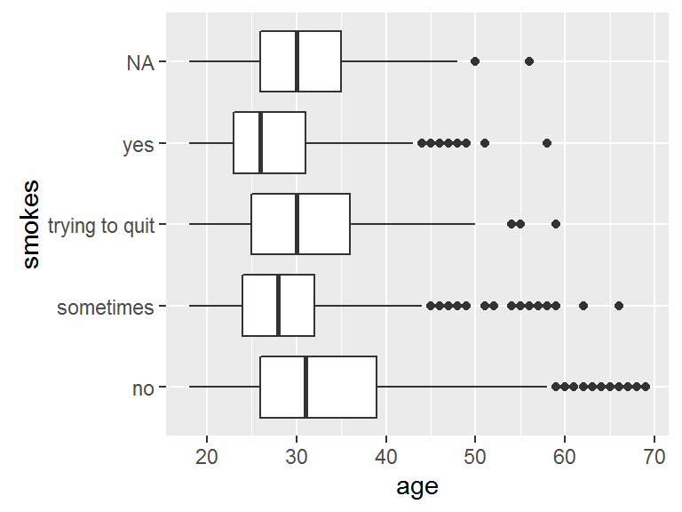

```r
ggplot(y, aes(smokes, age)) +
  geom_boxplot() +
  coord_flip()
```

- **Are druggies more likely to smoke?**

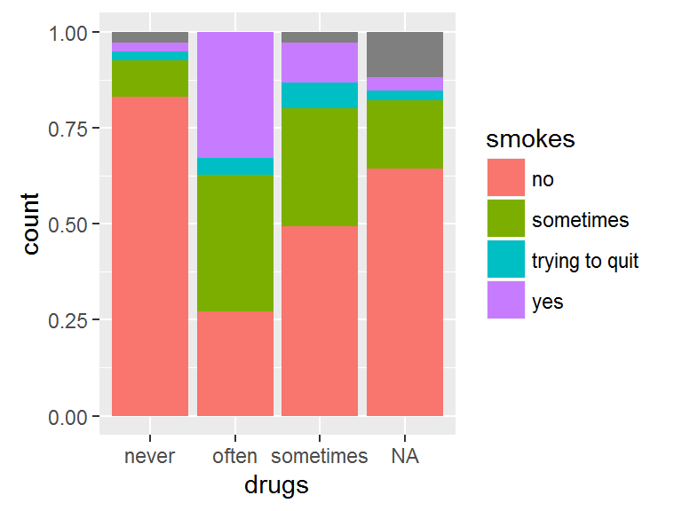

```r
ggplot(y, aes(drugs, fill=smokes)) +
  geom_bar(position = "fill")
```

- **Are vegans (`diet`) more likely to be thin (`body_type`)?**

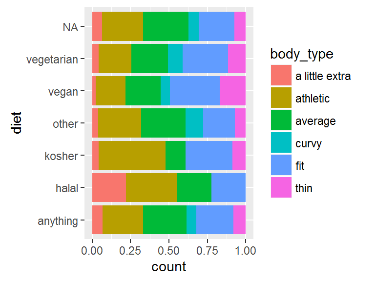

```r
ggplot(y, aes(diet, fill=body_type)) +
  geom_bar(position = "fill") +
  coord_flip()
```

- **Are girls (`sex`) smarter/dumber (`education`) than guys?**

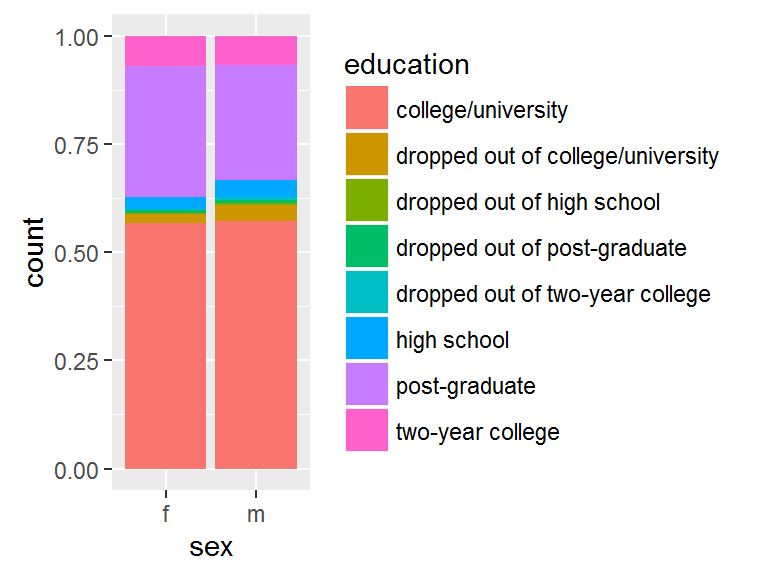

```r
ggplot(y, aes(sex, fill=education)) +
  geom_bar(position = "fill")
```

- **What is the correlation coefficient between `age` and `offspring`? Is this expected?** (offspring = # of children)

```r
cor(y$age, y$offspring, use = "complete")
```

```
## [1] 0.5188177
```

### And finally…

If you enjoyed this dataset… imagine what it would be like to actually work at OkCupid and analyze millions of users instead of a pitiful 5000. Or how about analyzing Tinder data? Or Facebook data? Welcome to the world of Data Science.